# Hayman Fire Recovery

Anna Marshall

02 February, 2022

# Overview

The Hayman Fire was a forest fire started on June 8, 2002, 35 miles northwest of Colorado Springs, Colorado. Below is a graphical analysis looking at some pre and post-fire changes.

## Q1. Correlation between NDVI and NDMI

The NDVI is correlated with the NDMI. A higher NDMI should result in a higher NDVI. In other words, more moisture will result in a higher amount of greeness. More precipitation and wetter soils means vegetation can grow more effectively. However, we see a different relationship post-burn.

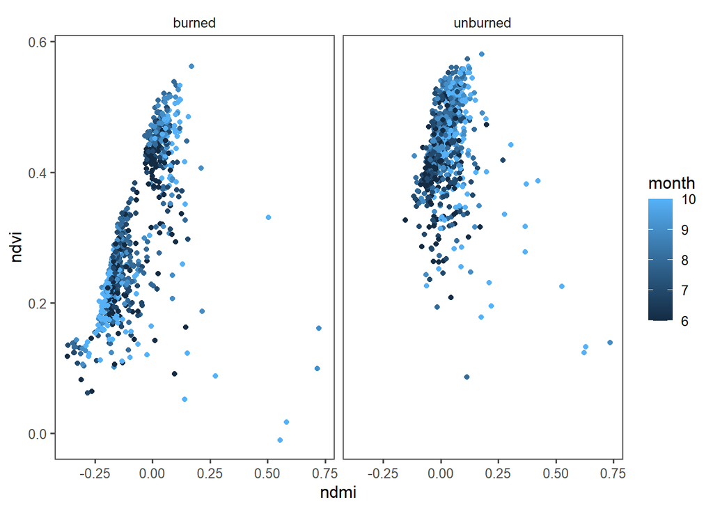

```r
##convert full_long dataset to wide format
data_wide<-spread(full_long,data,value)%>%
  mutate(month=month(DateTime),
         year = year(DateTime),
         treatment = cut(year,breaks=c(0,2003,2020),
                         labels=c('pre-burn','post-burn')))


## Plot of moisture (ndmi) vs greenness (ndvi) for burned area
data_wide %>%
  filter(!month %in% c(11,12,1,2,3,4,5)) %>%
ggplot(.,aes(x=ndmi,y=ndvi,color=month)) +
  geom_point()+
  facet_wrap(~site)+
  theme_few()
```

## Q2. Correlation between average NDSI (January-April) and NDVI (June-August)

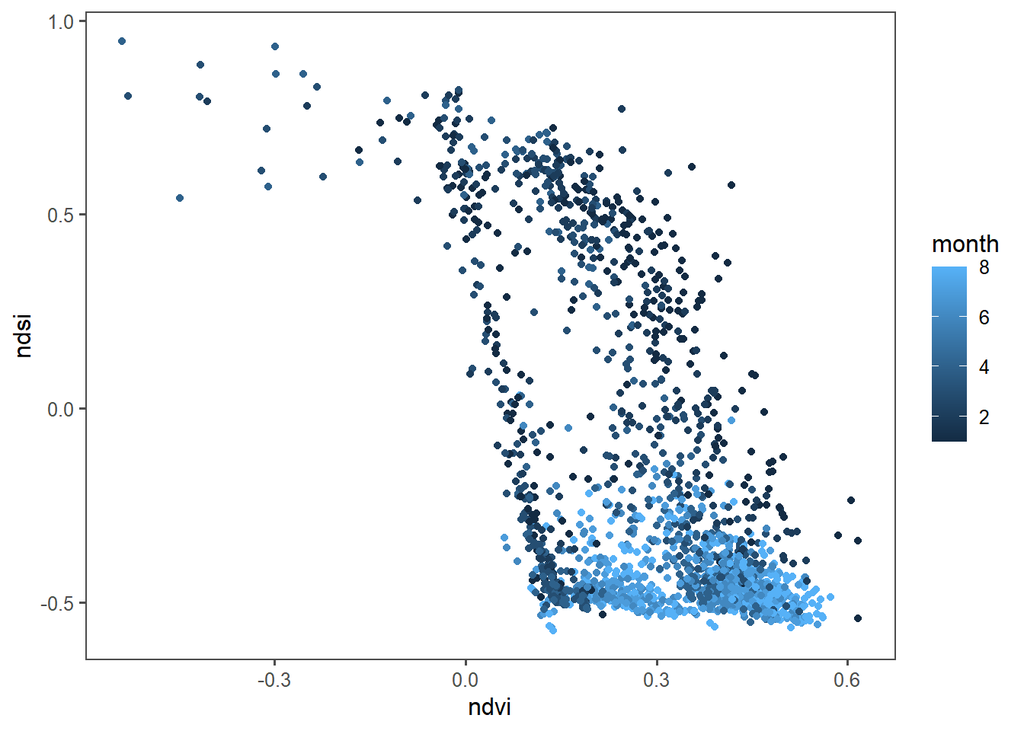

```r
## Plot of snow (ndsi) vs greenness (ndvi)
data_wide %>%
  filter(!month %in% c(5,9,10,11,12)) %>%
ggplot(.,aes(x=ndvi,y=ndsi,color=month)) +
  geom_point()+
  theme_few()
```

## Q3. Comparing snow effect between burned vs. unburned and pre- vs. post-burn.

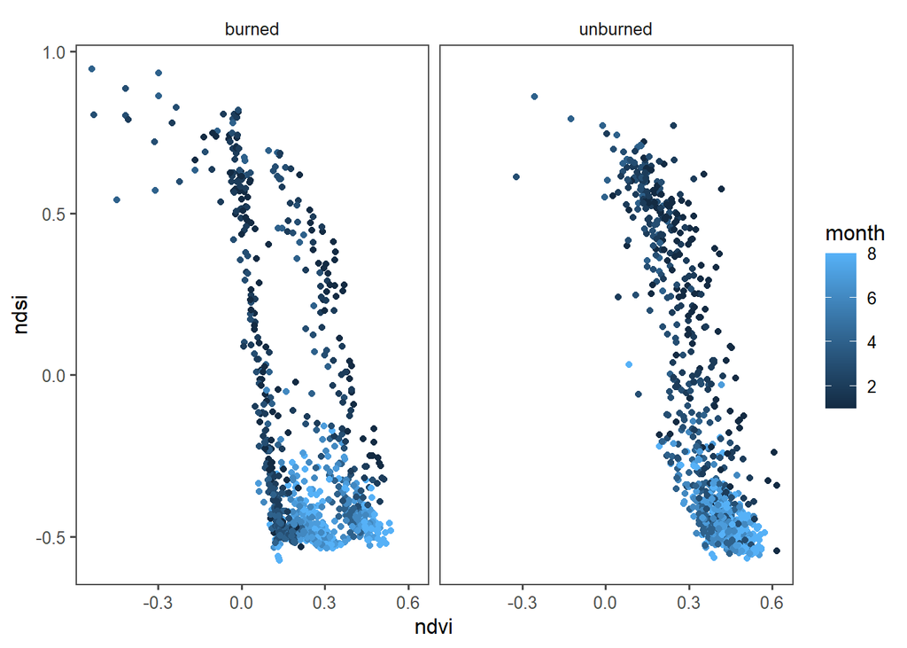

```r
## Plot of snow (ndsi) vs greenness (ndvi) seperated by burned vs. unburned
data_wide %>%
  filter(!month %in% c(5,9,10,11,12)) %>%
ggplot(.,aes(x=ndvi,y=ndsi,color=month)) +
  geom_point()+
  facet_wrap(~site)+
  theme_few()
```

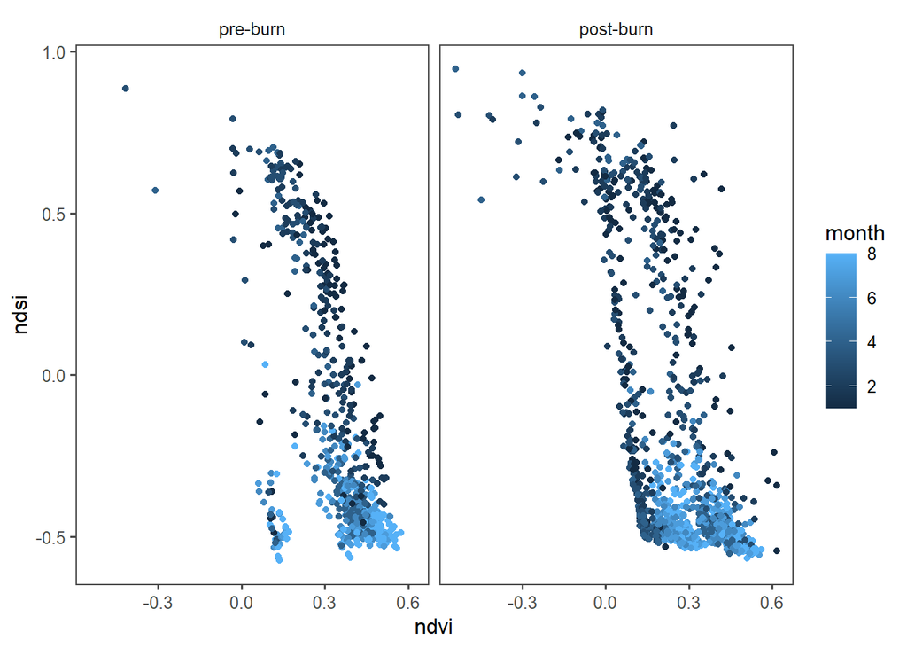

```r
## Plot of snow (ndsi) vs greenness (ndvi) seperated by pre- vs. post-burn
##Using 1984-2001 as pre-burn and 2002-2019 as post-burn
data_wide %>%
  filter(!month %in% c(5,9,10,11,12)) %>%
ggplot(.,aes(x=ndvi,y=ndsi,color=month)) +
  geom_point()+
  facet_wrap(~treatment)+
  theme_few()
```

## Q4. What month is the greenest month on average?

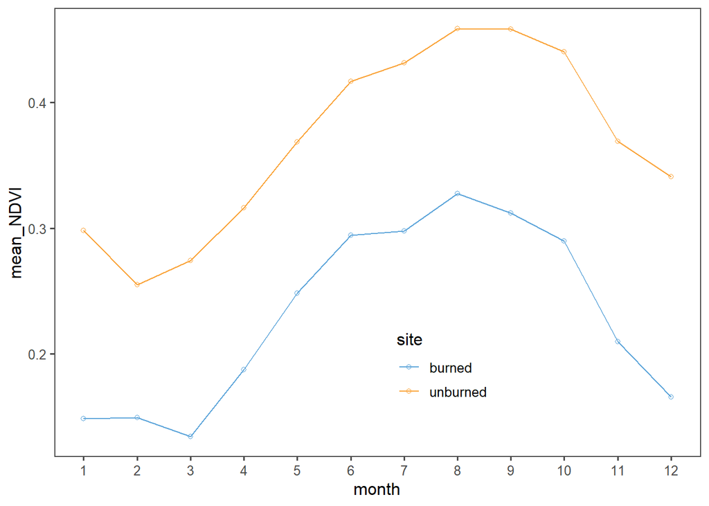

```r
# Plotting seasonal variation by summarizing over month instead of year
ndvi <- read_csv('data/hayman_ndvi.csv') %>%
  rename(burned=2,unburned=3) %>%
  filter(!is.na(burned),
         !is.na(unburned))

ndvi_long <- gather(ndvi,
                    key='site',
                    value='NDVI',
                    -DateTime)

ndvi_month <- ndvi_long %>%
  mutate(year=year(DateTime)) %>%
  mutate(month=month(DateTime)) %>%
  group_by(site,month) %>%
  summarize(mean_NDVI=mean(NDVI))

ggplot(ndvi_month,aes(x=month,y=mean_NDVI,color=site)) +
  geom_point(shape=1) +
  geom_line() +
  theme_few() +
  scale_color_few() +
  scale_x_continuous(breaks=seq(1,12,1))+
  theme(legend.position=c(0.6,0.2))
```

## Q5. What month is the snowiest on average?

In the unburned zone, February has the highest NDSI, while NDSI in the burned zone suggests a snowier January.

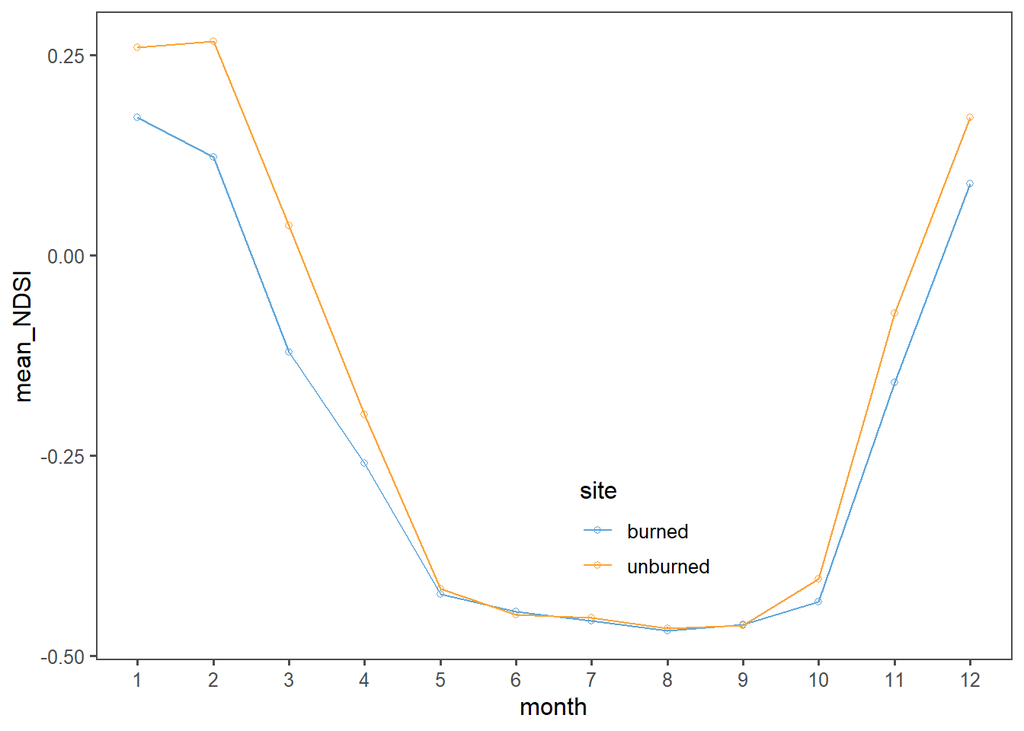

```r
#Reading in the data.
ndsi <- read_csv('data/hayman_ndsi.csv') %>%
  rename(burned=2,unburned=3) %>%
  filter(!is.na(burned),
         !is.na(unburned))

# Converting from wide to long data
ndsi_long <- gather(ndsi,
                    key='site',
                    value='NDSI',
                    -DateTime)
# Plotting seasonal variation by summarizing over month instead of year
ndsi_month <- ndsi_long %>%
  mutate(year=year(DateTime)) %>%
  mutate(month=month(DateTime)) %>%
  group_by(site,month) %>%
  summarize(mean_NDSI=mean(NDSI))

# Same plot as above but with month on x-axis
ggplot(ndsi_month,aes(x=month,y=mean_NDSI,color=site)) +
  geom_point(shape=1) +
  geom_line() +
  theme_few() +
  scale_color_few() +
  scale_x_continuous(breaks=seq(1,12,1))+
  theme(legend.position=c(0.6,0.2))
```

## Bonus Question: Redo all problems with `spread` and `gather` using modern tidyverse syntax.

Modern tidyverse syntax uses pivot_wider() and pivot_longer() to reshape data between wide and long formats. Check out the updated code below that utilizes this modern tidyverse syntax.

```r
#convert long data to wide
wide_pivot<-pivot_wider(full_long,names_from = "site", values_from = "value")%>%
  mutate(month=month(DateTime),
         year = year(DateTime),
         treatment = cut(year,breaks=c(0,2003,2020),
                         labels=c('pre-burn','post-burn')))
#convert wide data to long
full_wide%>%
  pivot_longer(burned_ndmi:unburned_ndsi,
              names_to="data",
              values_to='value',
              values_drop_na = TRUE)
```

```
## # A tibble: 9,540 x 5
##    DateTime   month  year data           value
##    <date>     <dbl> <dbl> <chr>          <dbl>
##  1 1984-04-10     4  1984 burned_ndmi   0.522
##  2 1984-04-10     4  1984 unburned_ndmi 0.669
##  3 1984-04-10     4  1984 burned_ndvi   0.200
##  4 1984-04-10     4  1984 unburned_ndvi 0.0964
##  5 1984-04-10     4  1984 burned_ndsi   0.361
##  6 1984-04-10     4  1984 unburned_ndsi 0.605
##  7 1984-06-06     6  1984 burned_ndmi   0.0285
##  8 1984-06-06     6  1984 unburned_ndmi 0.001
##  9 1984-06-06     6  1984 burned_ndvi   0.385
## 10 1984-06-06     6  1984 unburned_ndvi 0.392
## # ... with 9,530 more rows
```

## Bonus Question: Use Climage Engine to pull the same data for the assignment, but updated with 2020/2021 data.

Data has been updated in all graphs to include 2020/2021 data for NDVI, NDSI, and NDMI.